# Emotion_Recognition_

## Speech Emotion Recognition

```python
!apt-get update
!apt-get install -y libsndfile1

 # A C library for reading and writing audio files.
 # allows you to read and write audio files in various formats (e.g., WAV, FLAC, AIFF, etc.)
```

```python
import pandas as pd
import numpy as np

import os
import sys
# used for interacting with the operating system

# librosa is a Python library for analyzing audio and music. It can be used to extract the data from the audio files.
import librosa
import librosa.display
import seaborn as sns
import matplotlib.pyplot as plt

from sklearn.preprocessing import StandardScaler, OneHotEncoder
from sklearn.metrics import confusion_matrix, classification_report
from sklearn.model_selection import train_test_split

# to play the audio files
# This line imports the Audio class from IPython.display, which can be used to play audio files directly in a Jupyter Notebook or IPython environment.
from IPython.display import Audio


# if the validation loss plateaus, reducing the learning rate can help the model converge to a better solution.
from keras.callbacks import ReduceLROnPlateau
# is a Keras class that allows to create a linear stack of layers for building neural network models
from keras.models import Sequential

'''
Dense: A standard fully connected layer in a neural network. It contains multiple neurons connected to the previous and next layers.
Conv1D: A 1D convolutional layer, often used for processing sequences like audio data.
MaxPooling1D: A 1D max-pooling layer used for downsampling feature maps in convolutional neural networks.
Flatten: A layer used to flatten the output from previous layers into a 1D vector, typically before feeding it into a fully connected layer.
Dropout: A layer used for regularization by randomly dropping a certain percentage of neurons during training, preventing overfitting.
BatchNormalization: A layer used to normalize the activations in a neural network, improving training stability and speed.
'''
from keras.layers import Dense, Conv1D, MaxPooling1D, Flatten, Dropout, BatchNormalization

 # Is a utility function that converts class labels (integers) to one-hot encoded vectors.
 # Useful when you have a multi-class classification problem, and neural networks typically require one-hot encoding for the target variable.
from keras.utils import to_categorical

# is a callback used to save the model's weights during training.
# Helpful for resuming training, selecting the best model based on some criteria (e.g., validation accuracy).
# Ensures to have checkpoints in case of crashes or interruptions.
from keras.callbacks import ModelCheckpoint

# suppress warning messages
import warnings
if not sys.warnoptions:
    warnings.simplefilter("ignore")
warnings.filterwarnings("ignore", category=DeprecationWarning)
```

```python
# data is in '.wav' format
# .wav => waveform audio video file format - compressed + good quality (when compared to MP3)
Ravdess = "/content/drive/MyDrive/Colab Notebooks/ravdess-emotional-speech-audio/audio_speech_actors_01-24/"
```

```python
# to create a Pandas DataFrame that associates each file with an emotion label
ravdess_directory_list = os.listdir(Ravdess)

file_emotion = []
file_path = []

for dir in ravdess_directory_list:
    # as there are 20 different actors in our previous directory we need to extract files for each actor.
    # 'dir' represents the actor's subdirectory.
    actor = os.listdir(Ravdess + dir)
    for file in actor:
        part = file.split('.')[0] # removes file extension '.wav'
        # It splits the remaining filename part by hyphens to extract relevant information.
        part = part.split('-')
        # The third part in each file represents the emotion label associated with that file.
        file_emotion.append(int(part[2]))
        # base directory (Ravdess), the actor's subdirectory (dir), and the filename (file).
        file_path.append(Ravdess + dir + '/' + file)

# dataframe for emotion of files
emotion_df = pd.DataFrame(file_emotion, columns=['Emotions'])

# dataframe for path of files.
path_df = pd.DataFrame(file_path, columns=['Path'])
Ravdess_df = pd.concat([emotion_df, path_df], axis=1) # column axis

# changing integers to actual emotions.
Ravdess_df.Emotions.replace({1:'neutral', 2:'calm', 3:'happy', 4:'sad', 5:'angry', 6:'fear', 7:'disgust', 8:'surprise'}, inplace=True)
Ravdess_df.head()
```

|  | Emotions | Path |
| --- | --- | --- |
| 0 | neutral | /content/drive/MyDrive/Colab Notebooks/ravdess... |
| 1 | neutral | /content/drive/MyDrive/Colab Notebooks/ravdess... |
| 2 | calm | /content/drive/MyDrive/Colab Notebooks/ravdess... |
| 3 | calm | /content/drive/MyDrive/Colab Notebooks/ravdess... |
| 4 | happy | /content/drive/MyDrive/Colab Notebooks/ravdess... |

```python
data_path = pd.concat([Ravdess_df], axis = 0)
data_path.to_csv("data_path.csv",index=False)
data_path.shape
```

```
(1447, 2)
```

### Data Visualisation

```python
data_path.head()
```

|  | Emotions | Path |
| --- | --- | --- |
| 0 | neutral | /content/drive/MyDrive/Colab Notebooks/ravdess... |
| 1 | neutral | /content/drive/MyDrive/Colab Notebooks/ravdess... |
| 2 | calm | /content/drive/MyDrive/Colab Notebooks/ravdess... |
| 3 | calm | /content/drive/MyDrive/Colab Notebooks/ravdess... |
| 4 | happy | /content/drive/MyDrive/Colab Notebooks/ravdess... |

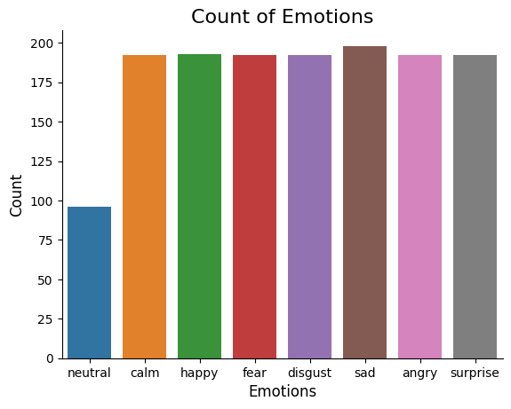

```python
plt.title('Count of Emotions', size=16)
sns.countplot(data=data_path, x='Emotions')
plt.ylabel('Count', size=12)
plt.xlabel('Emotions', size=12)
sns.despine(top=True, right=True, left=False, bottom=False)
plt.show()
```

### Data Augmentation

- Data augmentation is the process by which we create new synthetic data samples by adding small perturbations on our initial training set.
- To generate syntactic data for audio, we can apply noise injection, shifting time, changing pitch and speed.
- The objective is to make our model invariant to those perturbations and enhace its ability to generalize.
- In order to this to work adding the perturbations must conserve the same label as the original training sample.
- In images data augmention can be performed by shifting the image, zooming, rotating ...

```python
def noise(data):
    # 3.5% of the maximum amplitude in the data.
    # Random noise is generated and added to the data.
    noise_amp = 0.035*np.random.uniform()*np.amax(data)
    data = data + noise_amp*np.random.normal(size=data.shape[0])
    return data

def stretch(data, rate=0.8):
    # change the duration of the audio by the specified rate.
    return librosa.effects.time_stretch(data, rate)


def shift(data):
    # shifts the audio signal in time by a random amount in milliseconds.
    shift_range = int(np.random.uniform(low=-5, high = 5)*1000)
    return np.roll(data, shift_range)

def pitch(data, sampling_rate, pitch_factor=0.7):
    return librosa.effects.pitch_shift(data, sampling_rate, pitch_factor)

# taking any example and checking for techniques.
path = np.array(data_path.Path)[1]
# data_path.Path accesses the "Path" column in the DataFrame.
# np. array(data_path.Path) converts the selected column into a NumPy array.
# [1] indexes the NumPy array to select the second item (arrays are 0-indexed).

data, sample_rate = librosa.load(path)
# data stores the audio signal as a one-dimensional NumPy array. It contains the amplitude values of the audio signal over time.
# sample_rate stores the sample rate of the audio data, representing the number of samples (amplitude values) per second.
```

[interactive chart not shown]

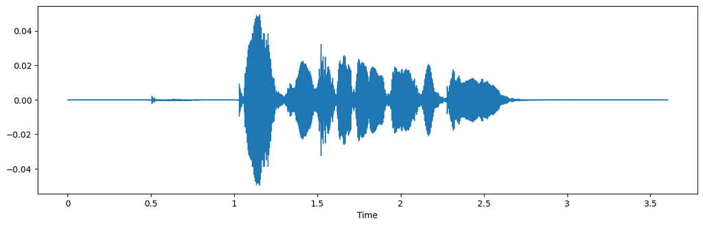

```python
plt.figure(figsize=(14,4))
librosa.display.waveshow(y=data, sr=sample_rate)
Audio(path)
```

[interactive chart not shown]

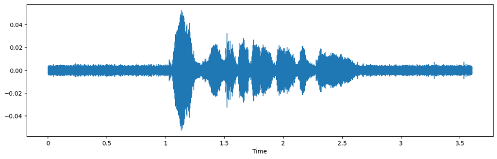

```python
x = noise(data)
plt.figure(figsize=(14,4))
librosa.display.waveshow(y=x, sr=sample_rate)
Audio(x, rate=sample_rate)
```

[interactive chart not shown]

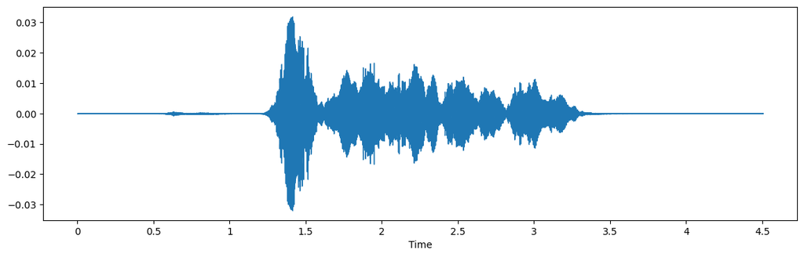

```python
x = librosa.effects.time_stretch(data, rate=0.8)
plt.figure(figsize=(14, 4))
librosa.display.waveshow(y=x, sr=sample_rate)
Audio(x, rate=sample_rate)
```

[interactive chart not shown]

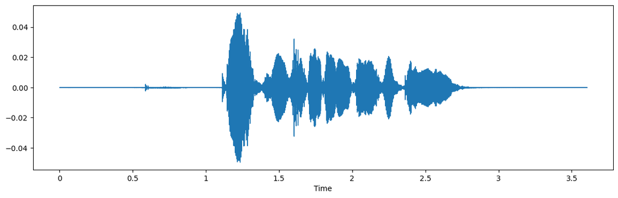

```python
x = shift(data)
plt.figure(figsize=(14,4))
librosa.display.waveshow(y=x, sr=sample_rate)
Audio(x, rate=sample_rate)
```

[interactive chart not shown]

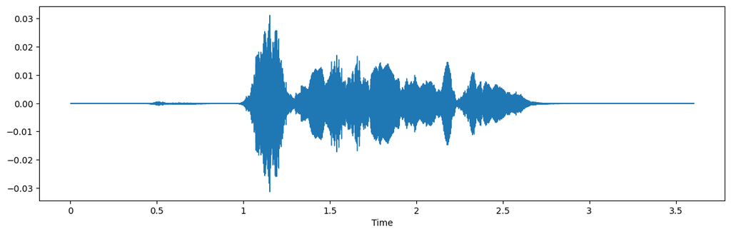

```python
x = librosa.effects.pitch_shift(data, sr=sample_rate, n_steps=3)
plt.figure(figsize=(14,4))
librosa.display.waveshow(y=x, sr=sample_rate)
Audio(x, rate=sample_rate)
```

## Feature Extraction

- The data provided of audio cannot be understood by the models directly so we need to convert them into an understandable format for which feature extraction is used.

Extracting 5 features:

- Zero Crossing Rate
- Chroma_stft
- MFCC
- RMS(root mean square) value
- MelSpectogram to train our model.

```python
def extract_features(data):
    # ZCR - noise range
    result = np.array([])
    zcr = np.mean(librosa.feature.zero_crossing_rate(y=data).T, axis=0)
    result=np.hstack((result, zcr)) # stacking horizontally

    # Chroma_stft - pitch intensity
    stft = np.abs(librosa.stft(data))
    chroma_stft = np.mean(librosa.feature.chroma_stft(S=stft, sr=sample_rate).T, axis=0)
    result = np.hstack((result, chroma_stft)) # stacking horizontally

    # MFCC - Mel-frequency Cepstral Coefficients
    # The audio signal is divided into short overlapping frames, typically lasting around 20 to 40 milliseconds each.
    # These frames are often processed to check the amt of vibration at each individual frequency
    mfcc = np.mean(librosa.feature.mfcc(y=data, sr=sample_rate).T, axis=0)
    result = np.hstack((result, mfcc)) # stacking horizontally

    # Root Mean Square Value - average energy or intensity of the signal
    rms = np.mean(librosa.feature.rms(y=data).T, axis=0)
    result = np.hstack((result, rms)) # stacking horizontally

    # MelSpectogram
    # how the frequency content of a signal changes over time.
    mel = np.mean(librosa.feature.melspectrogram(y=data, sr=sample_rate).T, axis=0)
    result = np.hstack((result, mel)) # stacking horizontally

    return result

def get_features(path):
    # duration and offset are used to take care of the no audio in start and the ending of each audio files as seen above.
    data, sample_rate = librosa.load(path, duration=2.5, offset=0.6)

    # without augmentation
    res1 = extract_features(data)
    result = np.array(res1)

    # data with noise
    noise_data = noise(data)
    res2 = extract_features(noise_data)
    result = np.vstack((result, res2)) # stacking vertically

    # data with stretching and pitching
    new_data = librosa.effects.time_stretch(data, rate=0.8)
    data_stretch_pitch = librosa.effects.pitch_shift(new_data, sr=sample_rate, n_steps=3)
    res3 = extract_features(data_stretch_pitch)
    result = np.vstack((result, res3)) # stacking vertically

    return result
```

```python
print(data_path.shape)
data_path.head()
```

```
(1447, 2)
```

|  | Emotions | Path |
| --- | --- | --- |
| 0 | neutral | /content/drive/MyDrive/Colab Notebooks/ravdess... |
| 1 | neutral | /content/drive/MyDrive/Colab Notebooks/ravdess... |
| 2 | calm | /content/drive/MyDrive/Colab Notebooks/ravdess... |
| 3 | calm | /content/drive/MyDrive/Colab Notebooks/ravdess... |
| 4 | happy | /content/drive/MyDrive/Colab Notebooks/ravdess... |

```python
data_path['Emotions'].value_counts()
```

```
sad         198
happy       193
calm        192
fear        192
disgust     192
angry       192
surprise    192
neutral      96
Name: Emotions, dtype: int64
```

```python
X, Y = [], []
for path, emotion in zip(data_path.Path, data_path.Emotions):
    print(path," : ",emotion)
    feature = get_features(path)
#     print(feature)
    for ele in feature:
        X.append(ele)
        # appending emotion 3 times as we have made 3 augmentation techniques on each audio file.
        Y.append(emotion)
```

[output not shown]

[output cut: 1392 more lines]

[output not shown]

```python
len(X), len(Y), data_path.Path.shape
```

```
(4341, 4341, (1447,))
```

```python
Features = pd.DataFrame(X)
Features['labels'] = Y
Features.to_csv('features.csv', index=False)
Features.head()
```

|  | 0 | 1 | 2 | 3 | 4 | 5 | 6 | 7 | 8 | 9 | ... | 153 | 154 | 155 | 156 | 157 | 158 | 159 | 160 | 161 | labels |
| --- | --- | --- | --- | --- | --- | --- | --- | --- | --- | --- | --- | --- | --- | --- | --- | --- | --- | --- | --- | --- | --- |
| 0 | 0.221630 | 0.527198 | 0.493814 | 0.546133 | 0.516079 | 0.604708 | 0.639711 | 0.568550 | 0.608285 | 0.591129 | ... | 0.000020 | 0.000031 | 0.000015 | 0.000018 | 0.000017 | 0.000019 | 0.000026 | 0.000034 | 3.172760e-06 | neutral |
| 1 | 0.269278 | 0.624469 | 0.630949 | 0.646172 | 0.608084 | 0.702362 | 0.699906 | 0.615318 | 0.637861 | 0.609055 | ... | 0.000048 | 0.000059 | 0.000043 | 0.000045 | 0.000044 | 0.000047 | 0.000053 | 0.000064 | 3.000301e-05 | neutral |
| 2 | 0.135207 | 0.574856 | 0.606332 | 0.559319 | 0.489078 | 0.501065 | 0.459516 | 0.513831 | 0.604117 | 0.544533 | ... | 0.000004 | 0.000006 | 0.000006 | 0.000005 | 0.000003 | 0.000003 | 0.000003 | 0.000002 | 2.706244e-07 | neutral |
| 3 | 0.228886 | 0.510709 | 0.492870 | 0.523622 | 0.618444 | 0.569511 | 0.614542 | 0.563917 | 0.664414 | 0.643391 | ... | 0.000059 | 0.000041 | 0.000050 | 0.000089 | 0.000173 | 0.000262 | 0.000148 | 0.000061 | 2.786638e-06 | neutral |
| 4 | 0.268934 | 0.605976 | 0.580508 | 0.645570 | 0.703700 | 0.686886 | 0.646963 | 0.596214 | 0.667170 | 0.631523 | ... | 0.000085 | 0.000064 | 0.000078 | 0.000116 | 0.000198 | 0.000287 | 0.000173 | 0.000087 | 2.958857e-05 | neutral |

5 rows × 163 columns

Each feature column provides information about a specific aspect of the audio signal's characteristics within a short time frame (e.g., a few milliseconds).

```python
X = Features.iloc[: ,:-1].values
Y = Features['labels'].values
```

```python
# As this is a multiclass classification problem onehotencoding our Y.
encoder = OneHotEncoder()
Y = encoder.fit_transform(np.array(Y).reshape(-1,1)).toarray()
```

```python
# splitting data
x_train, x_test, y_train, y_test = train_test_split(X, Y, random_state=0, shuffle=True)
x_train.shape, y_train.shape, x_test.shape, y_test.shape
```

```
((3255, 162), (3255, 8), (1086, 162), (1086, 8))
```

```python
# scaling our data with sklearn's Standard scaler
scaler = StandardScaler()
x_train = scaler.fit_transform(x_train)
x_test = scaler.transform(x_test)
x_train.shape, y_train.shape, x_test.shape, y_test.shape
```

```
((3255, 162), (3255, 8), (1086, 162), (1086, 8))
```

```python
x_train.shape
```

```
(3255, 162)
```

```python
# making our data compatible to model.
x_train = np.expand_dims(x_train, axis=2)
x_test = np.expand_dims(x_test, axis=2)
x_train.shape, y_train.shape, x_test.shape, y_test.shape
```

```
((3255, 162, 1), (3255, 8), (1086, 162, 1), (1086, 8))
```

```python
'''
Dense: A standard fully connected layer in a neural network. It contains multiple neurons connected to the previous and next layers.
Conv1D: A 1D convolutional layer, often used for processing sequences like audio data.
MaxPooling1D: A 1D max-pooling layer used for downsampling feature maps in convolutional neural networks.
Flatten: A layer used to flatten the output from previous layers into a 1D vector, typically before feeding it into a fully connected layer.
Dropout: A layer used for regularization by randomly dropping a certain percentage of neurons during training, preventing overfitting.
BatchNormalization: A layer used to normalize the activations in a neural network, improving training stability and speed.

'''

model=Sequential()
model.add(Conv1D(256, kernel_size=5, strides=1, padding='same', activation='relu', input_shape=(x_train.shape[1], 1)))
model.add(MaxPooling1D(pool_size=5, strides = 2, padding = 'same'))

model.add(Conv1D(256, kernel_size=5, strides=1, padding='same', activation='relu'))
model.add(MaxPooling1D(pool_size=5, strides = 2, padding = 'same'))

model.add(Conv1D(128, kernel_size=5, strides=1, padding='same', activation='relu'))
model.add(MaxPooling1D(pool_size=5, strides = 2, padding = 'same'))
model.add(Dropout(0.2))

model.add(Conv1D(64, kernel_size=5, strides=1, padding='same', activation='relu'))
model.add(MaxPooling1D(pool_size=5, strides = 2, padding = 'same'))

model.add(Flatten())
model.add(Dense(units=32, activation='relu'))
model.add(Dropout(0.3))

model.add(Dense(units=8, activation='softmax'))
model.compile(optimizer = 'adam' , loss = 'categorical_crossentropy' , metrics = ['accuracy'])

model.summary()
```

```
Model: "sequential_3"
_________________________________________________________________
 Layer (type)                Output Shape              Param #
=================================================================
 conv1d_12 (Conv1D)          (None, 162, 256)          1536

 max_pooling1d_12 (MaxPooli  (None, 81, 256)           0
 ng1D)

 conv1d_13 (Conv1D)          (None, 81, 256)           327936

 max_pooling1d_13 (MaxPooli  (None, 41, 256)           0
 ng1D)

 conv1d_14 (Conv1D)          (None, 41, 128)           163968

 max_pooling1d_14 (MaxPooli  (None, 21, 128)           0
 ng1D)

 dropout_6 (Dropout)         (None, 21, 128)           0

 conv1d_15 (Conv1D)          (None, 21, 64)            41024

 max_pooling1d_15 (MaxPooli  (None, 11, 64)            0
 ng1D)

 flatten_3 (Flatten)         (None, 704)               0

 dense_6 (Dense)             (None, 32)                22560

 dropout_7 (Dropout)         (None, 32)                0

 dense_7 (Dense)             (None, 8)                 264

=================================================================
Total params: 557288 (2.13 MB)
Trainable params: 557288 (2.13 MB)
Non-trainable params: 0 (0.00 Byte)
_________________________________________________________________
```

```python
rlrp = ReduceLROnPlateau(monitor='loss', factor=0.4, verbose=0, patience=2, min_lr=0.0000001)
history=model.fit(x_train, y_train, batch_size=64, epochs=50, validation_data=(x_test, y_test), callbacks=[rlrp])
```

```
Accuracy of our model on test data :  61.78637146949768 %
```

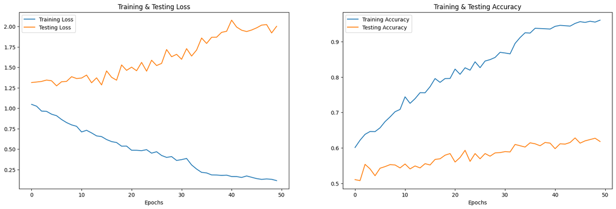

```python
print("Accuracy of our model on test data : " , model.evaluate(x_test,y_test)[1]*100 , "%")

epochs = [i for i in range(50)]
fig , ax = plt.subplots(1,2)
train_acc = history.history['accuracy']
train_loss = history.history['loss']
test_acc = history.history['val_accuracy']
test_loss = history.history['val_loss']

fig.set_size_inches(20,6)
ax[0].plot(epochs , train_loss , label = 'Training Loss')
ax[0].plot(epochs , test_loss , label = 'Testing Loss')
ax[0].set_title('Training & Testing Loss')
ax[0].legend()
ax[0].set_xlabel("Epochs")

ax[1].plot(epochs , train_acc , label = 'Training Accuracy')
ax[1].plot(epochs , test_acc , label = 'Testing Accuracy')
ax[1].set_title('Training & Testing Accuracy')
ax[1].legend()
ax[1].set_xlabel("Epochs")
plt.show()
```

```python
# predicting on test data.
pred_test = model.predict(x_test)
y_pred = encoder.inverse_transform(pred_test)
# to map the predicted numerical labels back to their original categorical labels or classes.
y_test = encoder.inverse_transform(y_test)
```

```python
df = pd.DataFrame(columns=['Predicted Labels', 'Actual Labels'])
df['Predicted Labels'] = y_pred.flatten()
df['Actual Labels'] = y_test.flatten()

df.head(10)
```

|  | Predicted Labels | Actual Labels |
| --- | --- | --- |
| 0 | angry | angry |
| 1 | sad | sad |
| 2 | calm | calm |
| 3 | calm | calm |
| 4 | happy | happy |
| 5 | disgust | angry |
| 6 | neutral | fear |
| 7 | happy | fear |
| 8 | disgust | disgust |
| 9 | happy | happy |

```python
print(classification_report(y_test, y_pred))
```

```
              precision    recall  f1-score   support

       angry       0.74      0.62      0.67       140
        calm       0.68      0.77      0.72       140
     disgust       0.52      0.64      0.58       131
        fear       0.64      0.59      0.61       145
       happy       0.52      0.55      0.54       143
     neutral       0.35      0.35      0.35        69
         sad       0.62      0.59      0.61       166
    surprise       0.76      0.70      0.73       152

    accuracy                           0.62      1086
   macro avg       0.60      0.60      0.60      1086
weighted avg       0.62      0.62      0.62      1086
```